# Task 2

Amelia Ritger

2/1/2020

## Task 2: Food nutrients

The following is an exploration of food nutrient information provided by the [USDA National Nutrient Database](https://fdc.nal.usda.gov/index.html). Specifically, I examine variation in nutrients (such as fat, vitamin E, and iron) present in baby food using a principal components analysis (PCA). Using a PCA will allow me to explore the multi-dimensionality of many nutrients (23, to be specific) present in baby food in a format that my adult brain can better comprehend.

#### So, let’s get started!

```r
#load the packages
library(tidyverse)
library(janitor)
library(naniar)
library(VIM)
library(skimr)
library(ggfortify)

#Input the data
food <- read_csv("usda_nutrients.csv")

#Take a look at the data
unique(food$FoodGroup)
```

```
##  [1] "Dairy and Egg Products"              "Spices and Herbs"
##  [3] "Baby Foods"                          "Fats and Oils"
##  [5] "Poultry Products"                    "Soups, Sauces, and Gravies"
##  [7] "Sausages and Luncheon Meats"         "Breakfast Cereals"
##  [9] "Snacks"                              "Fruits and Fruit Juices"
## [11] "Pork Products"                       "Vegetables and Vegetable Products"
## [13] "Nut and Seed Products"               "Beef Products"
## [15] "Beverages"                           "Finfish and Shellfish Products"
## [17] "Legumes and Legume Products"         "Lamb, Veal, and Game Products"
## [19] "Baked Products"                      "Sweets"
## [21] "Cereal Grains and Pasta"             "Fast Foods"
## [23] "Meals, Entrees, and Side Dishes"     "American Indian/Alaska Native Foods"
## [25] "Restaurant Foods"
```

It would be interesting to compare fast foods and restaurant foods. But that would mean running two PCAs *and ain’t nobody got time for that*… so let’s look at baby food!

#### Clean the data

```r
food_subset <- food %>%
  clean_names() %>%
  mutate(food_group = str_to_lower(food_group)) %>%
  filter(food_group == "baby foods") %>% #only look at baby food
  select(energy_kcal:zinc_mg) #choose variables to keep
```

#### Run the PCA

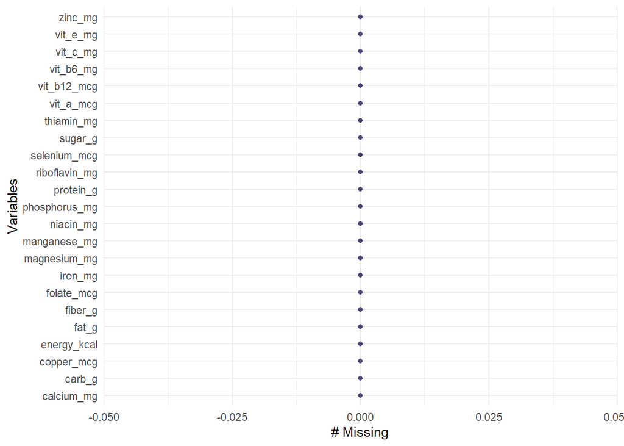

```r
food_pca <- prcomp(food_subset, scale=TRUE)

#Is there missingness?
naniar::gg_miss_var(food_subset) #nope!
```

```r
#Proportion of variance & cumulative variance explained by each PC
summary(food_pca)
```

```
## Importance of components:
##                           PC1    PC2    PC3     PC4     PC5     PC6     PC7
## Standard deviation     3.5678 1.9864 1.0072 0.96507 0.94867 0.81465 0.70345
## Proportion of Variance 0.5535 0.1716 0.0441 0.04049 0.03913 0.02885 0.02152
## Cumulative Proportion  0.5535 0.7250 0.7691 0.80961 0.84874 0.87760 0.89911
##                            PC8     PC9    PC10    PC11    PC12    PC13    PC14
## Standard deviation     0.65706 0.57426 0.49328 0.46338 0.42703 0.41429 0.36897
## Proportion of Variance 0.01877 0.01434 0.01058 0.00934 0.00793 0.00746 0.00592
## Cumulative Proportion  0.91788 0.93222 0.94280 0.95213 0.96006 0.96753 0.97344
##                           PC15    PC16    PC17    PC18    PC19    PC20    PC21
## Standard deviation     0.36158 0.35354 0.32335 0.29762 0.25092 0.20141 0.18732
## Proportion of Variance 0.00568 0.00543 0.00455 0.00385 0.00274 0.00176 0.00153
## Cumulative Proportion  0.97913 0.98456 0.98911 0.99296 0.99570 0.99746 0.99899
##                          PC22    PC23
## Standard deviation     0.1517 0.01721
## Proportion of Variance 0.0010 0.00001
## Cumulative Proportion  1.0000 1.00000
```

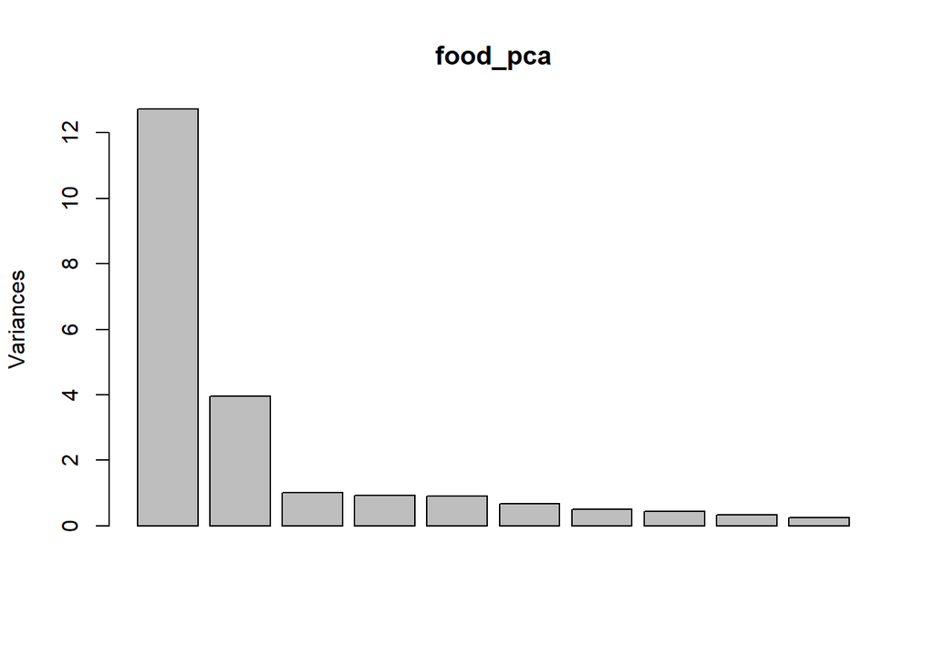

```r
#Visualize scree plot
plot(food_pca)
```

```r
# The amount of variation explained drops off dramatically after PC1, but even moreso after PC2.

#Rotations (linear combinations for each PC):
food_rotation <- food_pca
```

Dang, PC1 explains 55.3% of variance, and PC2 explains 17.2% of variance - that’s a lot of variance explained with just the first two principal components given we have 23 PCs to work with!

#### Plot the biplot

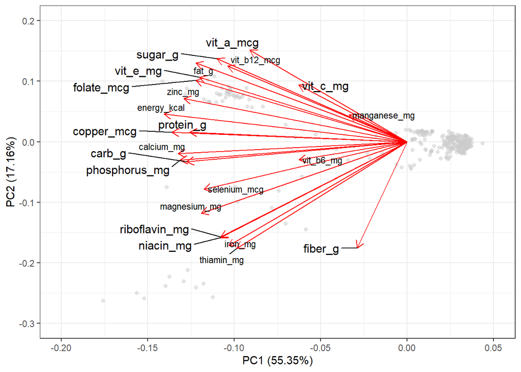

```r
autoplot(food_pca,
         colour = "grey80",
         loadings.label = TRUE,
         loadings.label.size = c(3,4,3,4,4,4,4,3,3,4,4,4,4,4,3,3,4,3,3,3,4,3,3),
         loadings.label.hjust = c(1,1,1,3,2,1.5,1,1,2,1,2,2,1,1.5,1,1,1.5,2,0.5,1,1,1,1),
         loadings.label.colour = "black",
         loadings.label.repel = TRUE,
         alpha = 0.5) +
  theme_bw() +
  scale_x_continuous(limits = c(-0.2, 0.05)) +
  scale_y_continuous(limits = c(-0.3, 0.2))
```

Figure 1. Principal components analysis (PCA) on food nutrients measured in baby food sold in the United States. Principal component 1 (PC1) accounted for 55.35% of variation in food nutrients, and principal component 2 (PC2) accounted for an additional 17.16% of food nutrient variation.

#### So, what does this mean?

In baby food, highly positively correlated nutrient pairs are: riboflavin and niacin, carbohydrates and phosphorus, copper and protein, vitamin E and folate, and sugar and vitamin B12. Fiber is minimally correlated with vitamin A, vitamin C, and manganese.

Additional research is needed to understand why vitamin B12 and sugar are so highly correlated in baby food…

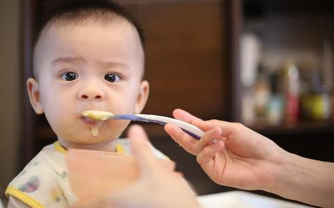

*I would give photo credit but* reverse image search this photo *and you’ll see why I am finding it difficult to do so.*